# Genome Analysis - Final Project

Logan Langholz

May 4, 2016

## Overview

The following was developed to explore genomic GC content as it relates to gene length. Using a combination of pybedtools and R, sequences from the coding regions of genes across all chromosomes from the hg19 reference genome were assesed for %GC content.

## Hypothesis

Because the translational stop codons (TAG, TAA, and TGA) feature less GC content, coding regions with a higher GC% will tend to be longer in length.

## Methods

#### Python Script:

The front end portion of this task was accomplished using the pybedtools suite within a python script. The output of the scritp was a .tsv file that contained chromosome, start interval, ending interval, gene name, gene length, and %GC content for each gene in hg19.

```python
#! usr/bin/env python

########################################################################
'''Creates table for all hg19 genes that contain:
1) Chromosome name 2) start 3) end 4)gene name 5) gene length 6) GC%'''
########################################################################

from __future__ import absolute_import, division, print_function
import pybedtools
import ipdb

#---------------------
# hg19 genes bed file:
test_file='/Users/loganlangholz/Documents/class_files/Graduate/Spring_2016/Genome_analysis/Projects/data-sets/bed/test.genes.hg19.bed.gz'
filename='/Users/loganlangholz/Documents/class_files/Graduate/Spring_2016/Genome_analysis/Projects/data-sets/bed/genes.hg19.bed.gz'

test_genes = pybedtools.BedTool(test_file)
genes = pybedtools.BedTool(filename)

#-----------------------------------------------------

# fxn to get GC content from chr and interval of record in bed file:
def GC_content(chrom, start, end):

    fasta_file = '/Volumes/My Book/Genome_Analysis-Final_Project/%s.fa' %chrom
    fasta = pybedtools.BedTool(fasta_file)

    bed = pybedtools.BedTool('%s\t%s\t%s' %(chrom, start, end), \
    from_string = True)

    nuc_content = bed.nucleotide_content(fasta)
    GC = float(nuc_content[0][4]) #GC% is index4 of the 1st and only feature

    return GC

#-------------------------------------------------------
#Create tsv file with Chrom, Gene Name, Gene Length:

fw = open('tbl_chr-genes.tsv', 'w')

for record in genes:

    chrom = str(record.chrom)

    length = record.length
    name = str(record.name)
    start = int(record.start)
    end = int(record.end)
    GC_percent = GC_content(chrom, record.start, record.end)

    fw.write('%s\t%d\t%d\t%s\t%d\t%f\n' %(chrom, start, end, name, length, GC_percent))

fw.close()
```

#### Import Data Into R-Studio

The next step was to import the generated .tsv file into R. Using dplyr and tidyr verbs, the data table was joined with a file containing chromosomes and their lengths. Each gene’s relative position along the chromosome was calculated by dividing the starting interval by the chromosome length. This data was used to explore any possible trends regarding GC content and relative chromosomal position.

```r
library(readr)
library(tidyr)
library(dplyr)
library(ggplot2)

#Table generated by python sript:
col_names <- c('chrom', 'start', 'stop', 'gene', 'gn_length', 'GC_content')
genes_length_gc <- read_tsv('tbl_chr-genes.tsv', col_names = col_names)

#Chromosome Lengths:
lengths_cols <- c('chrom', 'chr_length')
chrm_lengths <- read_tsv(
  '/Users/loganlangholz/Documents/class_files/Graduate/Spring_2016/Genome_analysis/Projects/data-sets/genome/hg19.genome', col_names = lengths_cols)

#Join tbls:
#new_tbl <- left_join(genes_length_gc, genes_bed, by = c('chrom', 'gene'))
master_tbl <- left_join(genes_length_gc, chrm_lengths, by = 'chrom')
master_tbl <- master_tbl %>% mutate(rel_position = start/chr_length)

#Threshold value for a 'large coding sequence':
lrg_gene_cutoff <- 2*(10^5)
```

## Generating Plots

All plots were generated using the following code. Data was split up in groups of four chromosomes at a time, to allow for better viewing. For the plots of GC content as a function of gene length, the trend line was modeled as y = log(x).

For plots showing GC content as a function of relative chromosomal position, data was again split into groups of four chromosomes at a time. All points were plotted in black, with a blue line representing the middle 50% GC line. Data points that had a gene length above a certain threshold, 200000bp, were overlayed and their color mapped as a funciton of log(gene length) on a gradient color scale (longest genes in yellow, shortest genes in red; all genes > 200000).

```r
#Chrs 1-4:
chrs <- c('chr1', 'chr2', 'chr3', 'chr4')
tbl_1_4 <- filter(master_tbl, master_tbl$chrom %in% chrs)

length_plot_1_4 <- ggplot(tbl_1_4, aes(gn_length, GC_content)) +
  geom_point(size = 1) +
  geom_smooth(method = 'lm', formula = y ~ log(x)) +
  facet_wrap(~chrom, ncol = 2, scales = 'free_x')

rel_pos_plot_1_4 <-ggplot(tbl_1_4, aes(rel_position, GC_content)) +
  geom_point( size = 1, alpha = 1/5) +
  geom_point(data = filter(tbl_1_4, tbl_1_4$gn_length > lrg_gene_cutoff), aes(color = log(gn_length)), size = .75) +
  scale_color_gradientn( sprintf("log(gn_length > %dbp)", lrg_gene_cutoff), colors = grDevices::heat.colors(5) ) +
  geom_segment(aes(x=0, y=0.5, xend = 1, yend = 0.5), color = 'blue', size = 0.25) +
  facet_wrap(~chrom, ncol = 2, scales = 'free_x')
```

## Plots

#### Correlation of %GC and Length:

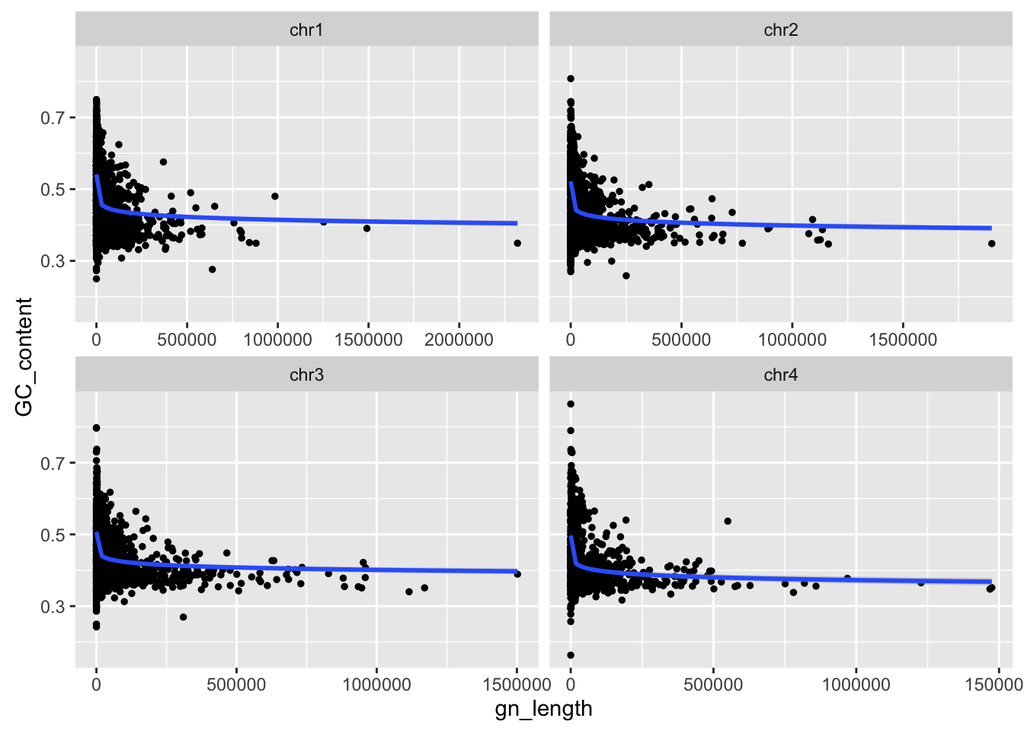

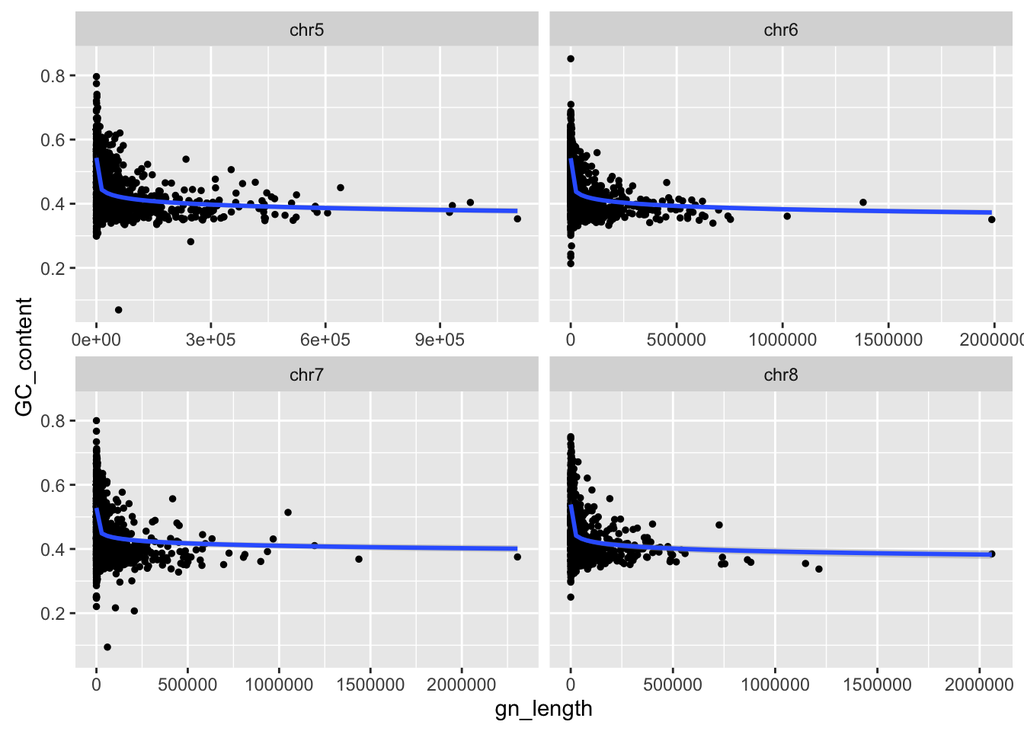

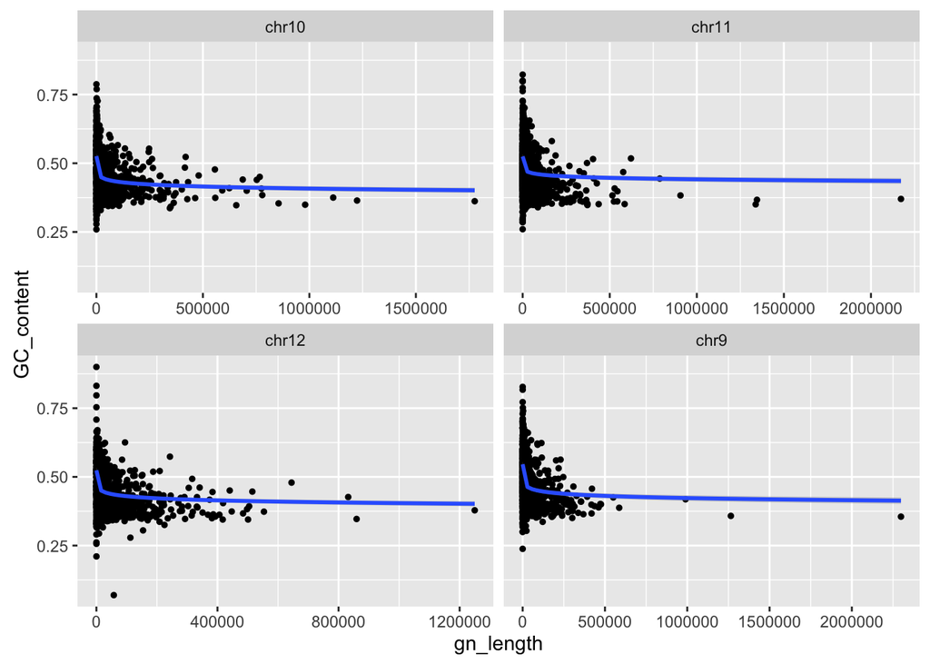

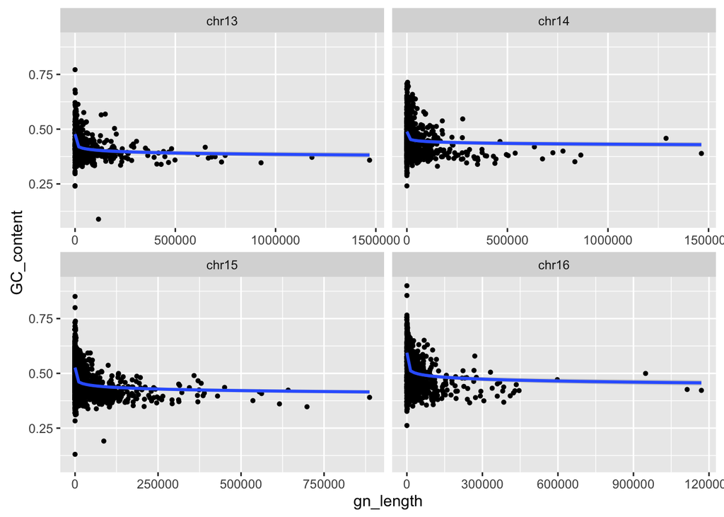

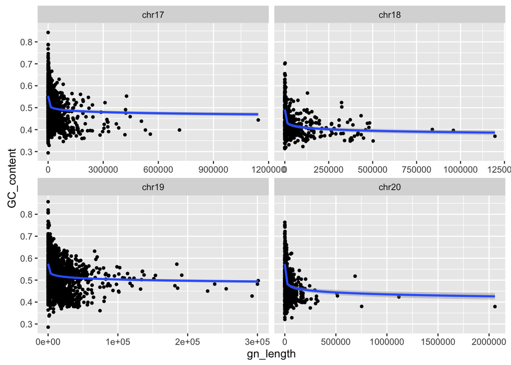

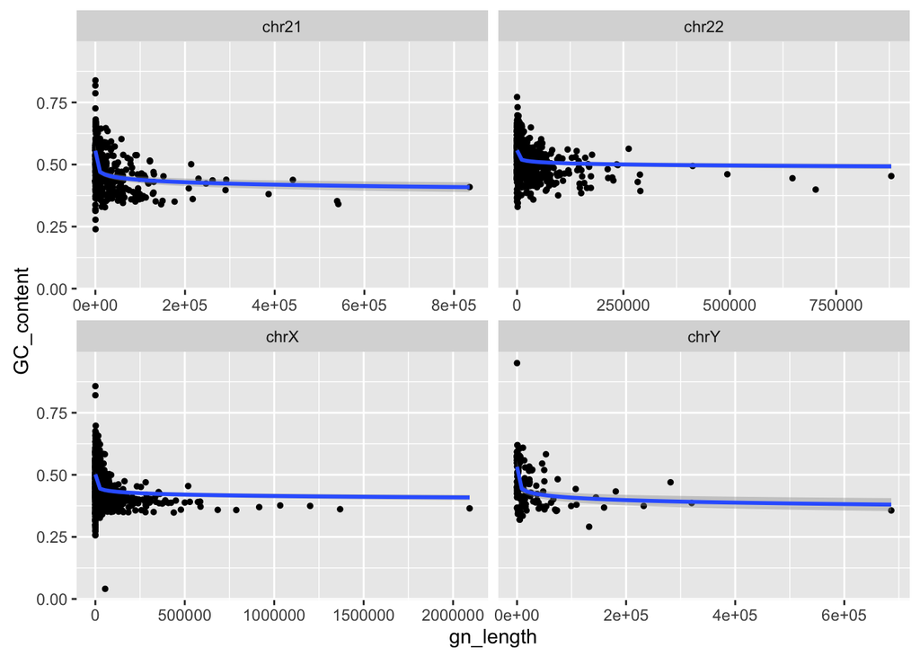

#### Relationship between %GC and relative chromosomal position:

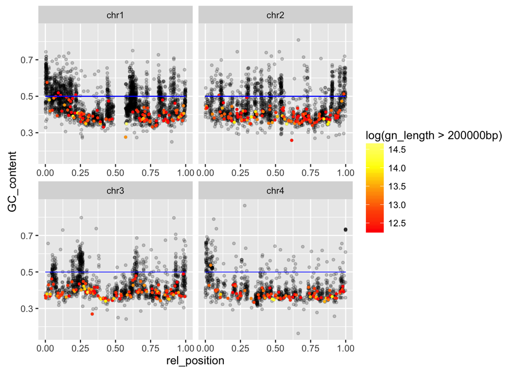

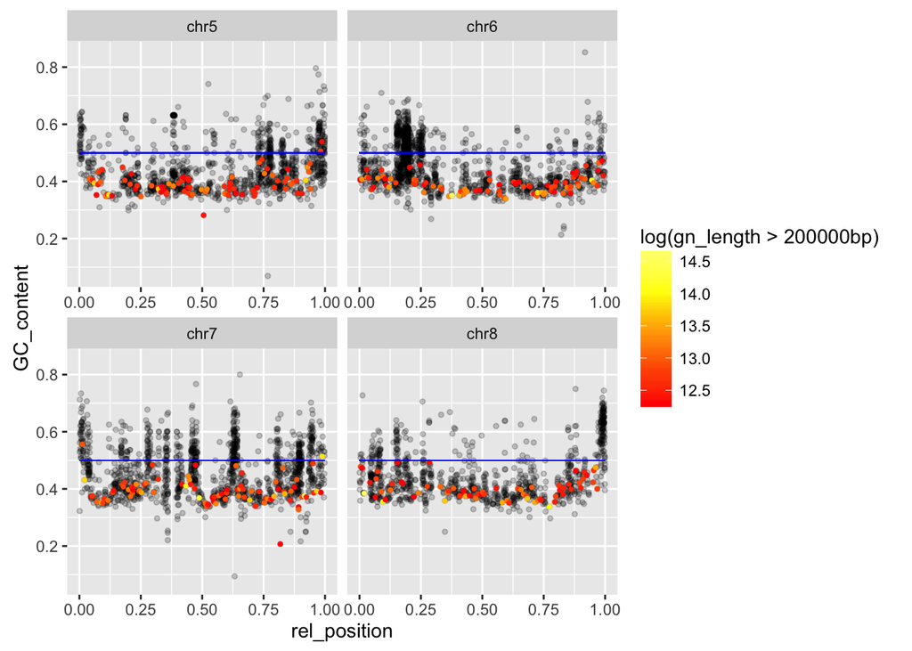

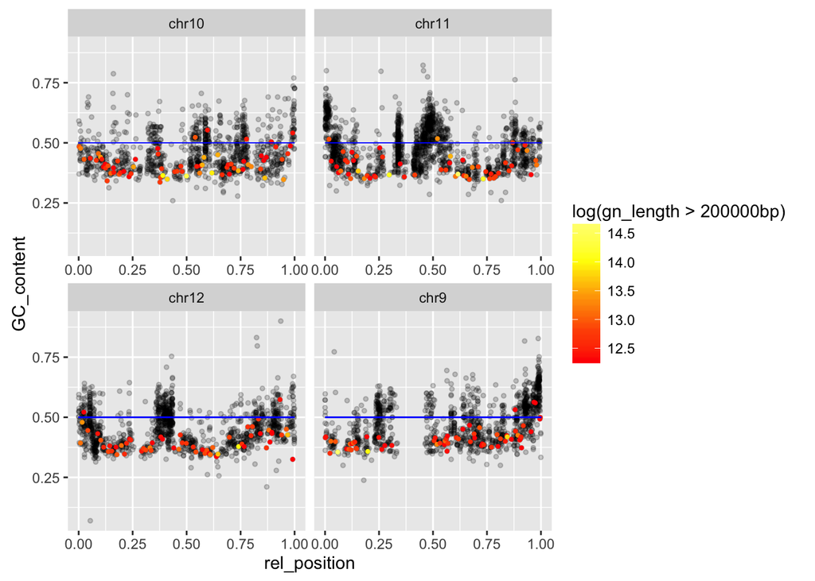

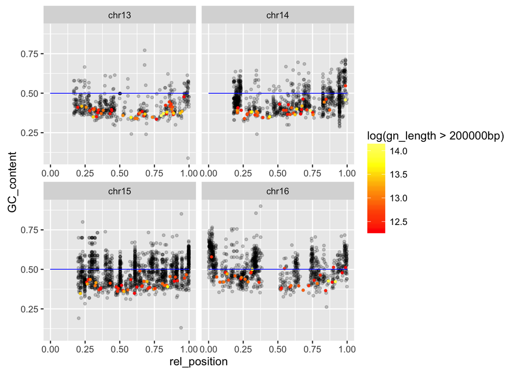

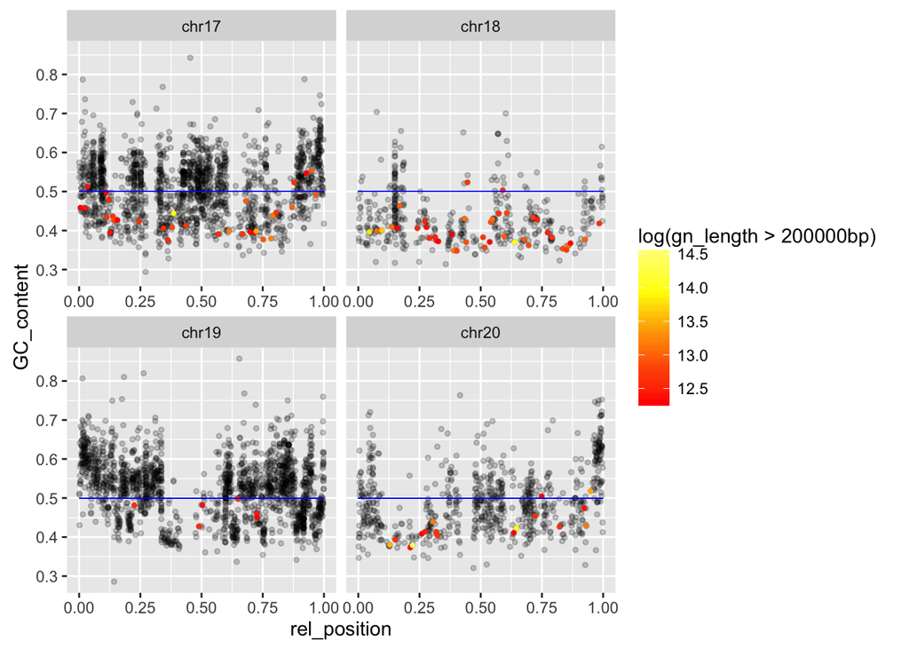

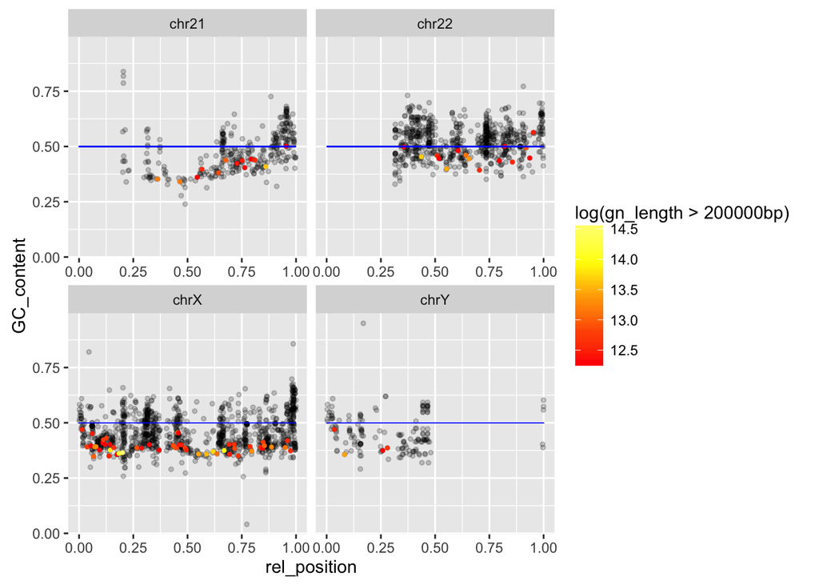